# Equation Solving

*ultimately want to discover n roots programatically*

##### helpful libs

```python
%matplotlib inline
import numpy as np
import matplotlib.pyplot as plt
from scipy.optimize import fsolve
```

## Finding a Single Root

In this small equation, **x** should correctly equal **5**.

**f(x)** is a coded representation of the written problem.  
**f(x)** takes a possible numeric solution as its only argument.  
if **f(x)** ever returns 2, then the guess is correct.

$$ -3 + x = 2 $$

```python
f = lambda x: -3 + x
```

### Brute Force Approach

First, I will solve for **x** with *brute force* guessing by passing various *guesses* into **f(x)** in form of array.

```python
xGuesses = np.array([1,2,3,4,5,6,7,8,9,10])

print("func results:", f(xGuesses))
```

```
func results: [-2 -1  0  1  2  3  4  5  6  7]
```

> Array output may shows the sequence of answers with respect to the input order  
> this will become the **y** position on the plot

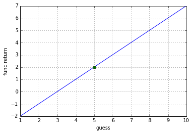

```python
plt.plot(xGuesses, f(xGuesses))
plt.plot(5, 2, 'o')
plt.xlabel("guess")
plt.ylabel("func return")
plt.grid()
plt.show()
```

> The grid shows that **5** **intersects** with **2**. Since our desired output is **2**, **5** is my answer.

Another way to discover a solution is to use *scipy* numerical solver to find the roots

Instead of visually hunting for the answer in a grid, one can simply be given a solution in plain text.

As far as I know, scipy.fsolve thinks that when a function returns "zero", then that is the correct solution Therefore, I must modify the equation to **equal zero** instead of 2.

$$ -3 + x -2 = 0 $$

```python
f = lambda x: -3 + x -2
```

```python
initial_guess = 1
solution = fsolve(f, initial_guess)

print ("The solution is x = %f" % solution)
```

```
The solution is x = 5.000000
```

> This is very similar to the homebrew brute force, except the *scipy* lib has some optimizations that are helpful.

## Finding Two Roots

*im not very good at this yet*

$$ 2y−3x =−27 $$$$ 5y+3x=6 $$

### Brute Force Matrix

so I was unable to figure out how to graph this problem in an intelligible way. I did figure out how to create a matrix with all possible combinations which allowed me to use the same **f(numpy.array)** strategy. I thought that the matrix should be called a *permutation matrix*, however, there already seems to be some advanced terminology that uses the same word for a different meaning. I recall it saying *"permute this matrix"*. I am still unsure what this means.

I am going to convert the equation to equal zero, so that i can use uniform solutions across differing equations

$$ A = 2y−3x+27 = 0 $$$$ B = 5y+3x-6 = 0 $$

```python
f = lambda x, y: (2*y) - (3*x) + 27
g = lambda x, y: (5*y) + (3*x) - 6
```

```python
possibleRange = list(range(-5, 10))

# n^r (permutations)
guessMatrix = np.array([np.repeat(possibleRange, len(possibleRange)),
                       np.tile(possibleRange, len(possibleRange))])

def findAnswers (f, matrix):
    matches = [i for i, x in enumerate(f(*matrix).tolist()) if x == 0]
    answers = []
    for i in matches:
        answers.append(str([matrix[0][i], matrix[1][i]]))
    return answers

A = findAnswers(f, guessMatrix)
B = findAnswers(g, guessMatrix)

print(A); print(B)
print(set(A).intersection(B))
```

```
['[7, -3]', '[9, 0]']
['[-3, 3]', '[2, 0]', '[7, -3]']
{'[7, -3]'}
```

> python's **set** class object is very useful for finding differences in collections. I had to serialize the return results so that the **set.intersection** comparison could be made. Fortunately for me, the **set.intersection** also returns **all** points, unlike the **list.index**

### numpy meshgrid

A matrix solution I found that did not work as expected was:

guessMatrix = np.array(np.meshgrid([1, 2, 3], [4, 5], [6, 7])).T.reshape(-1,3))

[1, 4, 6]  
[1, 5, 6]  
[2, 4, 6]  
[2, 5, 6]  
[3, 4, 6]  
[3, 5, 6]  
[1, 4, 7]  
[1, 5, 7]  
[2, 4, 7]  
[2, 5, 7]  
[3, 4, 7]  
[3, 5, 7]

[1, 4]  
[1, 5]  
[2, 4]  
[2, 5]  
[3, 4]  
[3, 5]

but since I needed the array to be in pivoted form of:

[1,1,2,2,3,3]  
[4,5,4,5,4,5]

I attempted to pivot the array using `reshape(2,-1)` with unexpected results:

[1, 4, 1, 5, 2, 4]  
[2, 5, 3, 4, 3, 5]

The was expecting a perfect pivot:

[1, 1, 2, 2, 3, 3]  
[4, 5, 4, 5, 4, 5]

Even though there may be a way to use these methods to achieve what i am looking for, ultimately it became unreadable and i lost my way.

**Brent suggested looking up matrix transformations**